# Lab 10: Filtering Data

## Pick a dataset

Today you will again have a choice of three datasets to work with. You can choose either to investigate the daily team ELO ratings in the NBA:

Metadata from US senator’s tweets:

Or swear words given in the movies of Quentin Tarantino:

Pick a dataset (feel free to delete the others from the Rmd file if you would like), and work on the instructions in the next section.

## Instructions

This lab is similar to the last. You’ll pick a dataset and then generate an analysis of that data using data visualizations. The difference here is that instead of a single plot, I would like you to construct 3-4 plots that together tell a linear story. Each plot should be separated by a sentence or two describing what the viewer should take away from the plot. Try to keep the plots similar in some way; perhaps each simply highlights a different subset of the data but has the same underlying layers.

Notice that each of the datasets for today are larger than you will probably be able to use. You will need to filter the data to a particular team, year, subset of curse words. You may further filter the data to highlight an even smaller subset of the data within each plot.

## Analysis

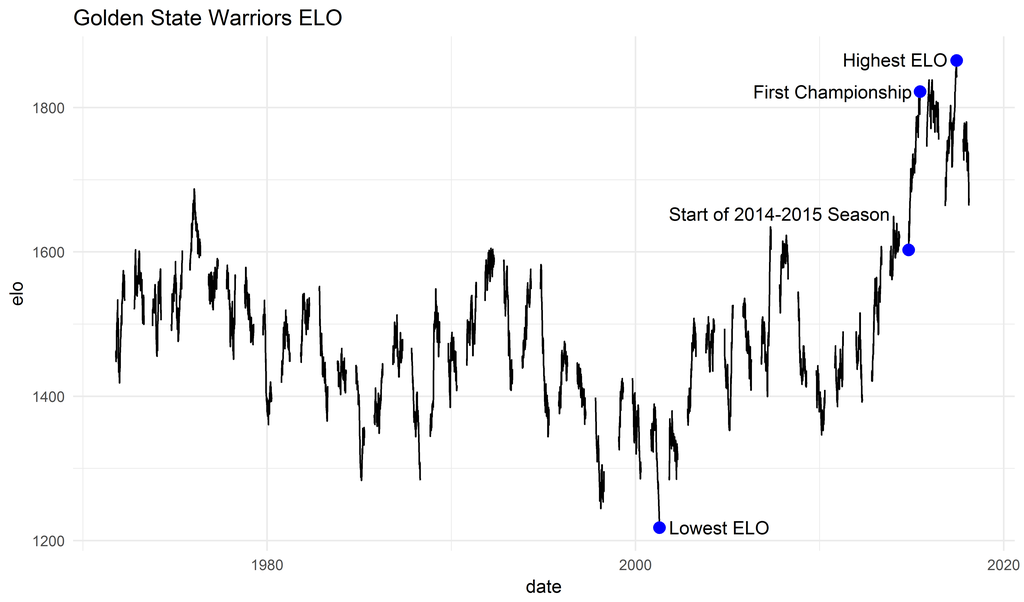

This plot shows the story of the skill level of the Golden State Warriors through its existance. The min is in 2001, and during that year, their final record was 21-51, finishing last in the West. On the contrary, their peak was in June 2017, which is when they won the championship.

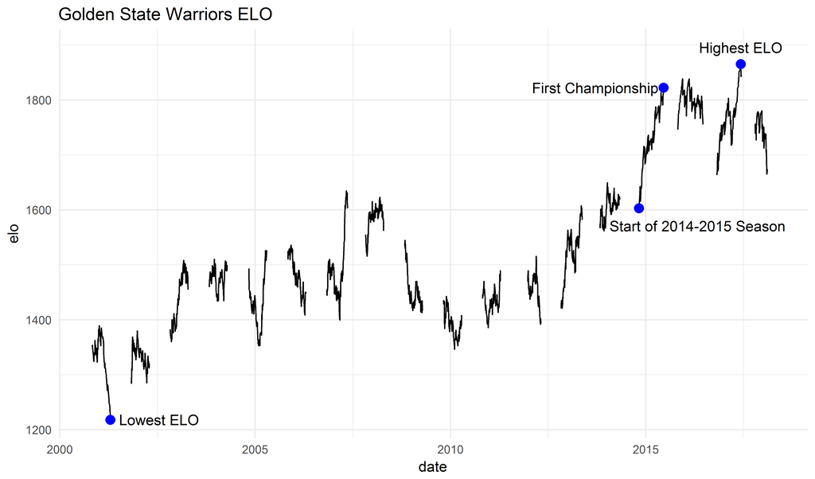

The graph shows the large jump in elo from winning the first championship in the 2014-2015 season. You can also see a similar looking pattern two seasons later, when they reach their highest recorded ELO by winning the championship in a record breaking fashion (12-1 record).

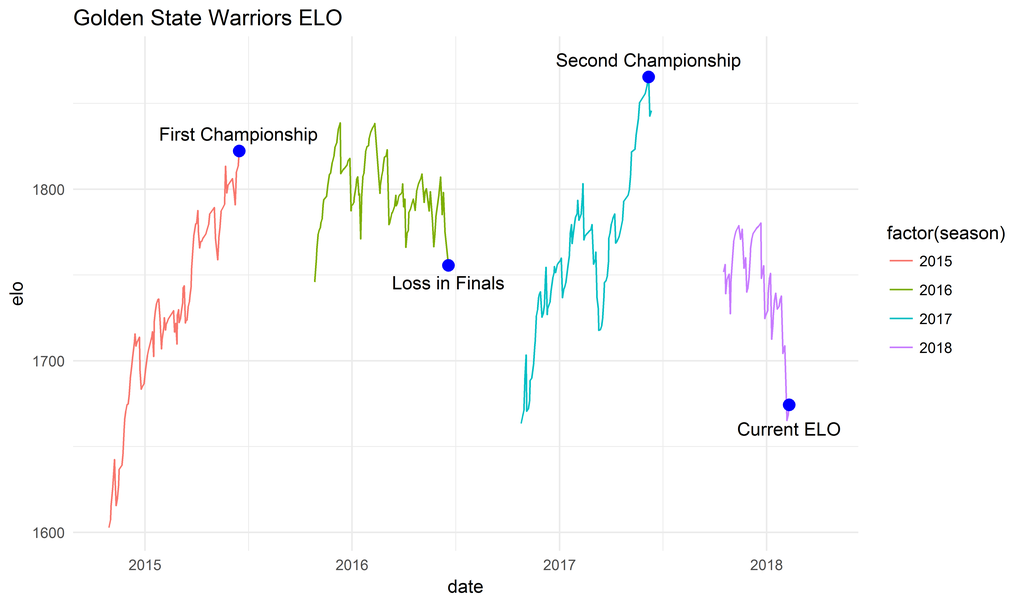

This graph breaks down the last 4 seasons to visualize the growth and fall of the Golden State Warriors ELO. The championships are straightforward, as they win, their elo grows. The drop from the second championship can be attributed as a result of losing one game to the Cleveland Cavaliers. In the 2016 season, the Warriors broke the single season regular season wins record, with 73 wins (73-9 record) and the results are shown with an elo that remains fairly consistant through the season. The large drop at the end is a result of throwing a 3-1 lead in the finals against the Cleveland Cavaliers. The Warriors are doing well this season and the drop in current elo is the result of losing 3 out of 4 games between January 30th and February 6th.